# A Brief Analysis on California’s Climate

### Introduction

Climate change is one of the largest environmental threats humanity has ever faced. The burning of fossil fuels and anthropogenic carbon emissions have contributed to a global atmospheric CO2 content of 405 ppm(parts per million) by 2017, around 40% higher than the pre-industrial level of 280ppm back in the mid-1700s . Climate change encompasses global phenomena such as increased temperatures, sea level rise, and extreme weather events such as droughts and monsoons. At this current pace, the extent of climate change effects may cause catastrophic environmental and societal damage as the earth systems struggle to adapt to this unprecedented rate of change. Although climate change is a global phenomenon, its impacts can very heterogenous across different regions. The chosen region for this detailed climate study was California. The first part of this analysis examines global and regional temperature trends using moving averages starting from 1895 to 2015. This is done primarily to visualize historical temperature trends and how California as a region compares to global average temperatures. Graphing historical temperature trends would also help show significant patterns The second part of the study draws relationships between climate parameters using statistical regression. California into temperature anomalies in California and how these may be correlated to atmospheric carbon dioxide levels and Palmer Drought Severity Index (PDSI) values, which use temperature and precipitation data to quantify long-term drought events. PDSI values can range anywhere from -10 (extreme dry conditions) and +10 (extreme wet conditions)

### DataSet

There are 4 datasets I scraped from the internet and used in the report

> 1. Global SST https://www.kaggle.com/berkeleyearth/climate-change-earth-surface-temperature-data
> 2. CITY/COUNTY SST https://www.kaggle.com/berkeleyearth/climate-change-earth-surface-temperature-data
> 3. CO2 atm level https://www.kaggle.com/ucsandiego/carbon-dioxide
> 4. PDSI https://www.esrl.noaa.gov/psd/data/index.html

# Part I Rolling trend comparison

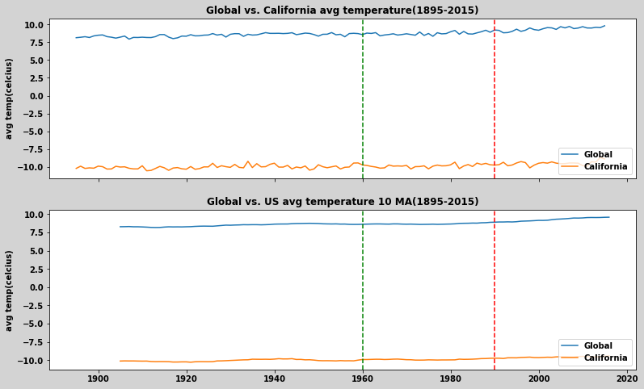

```python
#Californial VS. Global Average temperature(Rolling 10 MA AND trend)
fig, ax= plt.subplots(2,facecolor='lightgray', figsize=(13,8) ,sharex=True)
ax[0].plot(df_combine['year'], df_combine['avg_temp'], label='Global')
ax[0].plot(df_combine['year'], df_combine['avg_cal'], label='California')
ax[1].plot(rolling['year'], rolling['avg_temp'], label='Global')
ax[1].plot(rolling['year'], rolling['avg_cal'], label='California')
ax[0].set(title='Global vs. California avg temperature(1895-2015)',
         ylabel='avg temp(celcius)')
ax[1].set(title='Global vs. US avg temperature 10 MA(1895-2015)',
         ylabel='avg temp(celcius)')
ax[0].legend(loc='lower right')
ax[1].legend(loc='lower right')
ax[0].axvline(1960, color='g', linestyle='--')
ax[1].axvline(1960, color='g', linestyle='--')
ax[0].axvline(1990, color='r', linestyle='--')
ax[1].axvline(1990, color='r', linestyle='--');
```

# Part II Regression

```python
ca.describe()
```

|  | StateCode | Division | YearMonth | PCP | avg_temp | pdsi | PHDI | ZNDX | PMDI | CDD | ... | SP02 | SP03 | SP06 | SP09 | SP12 | SP24 | TMIN | TMAX | year | month |
| --- | --- | --- | --- | --- | --- | --- | --- | --- | --- | --- | --- | --- | --- | --- | --- | --- | --- | --- | --- | --- | --- |
| count | 684.0 | 684.0 | 684.000000 | 684.000000 | 684.000000 | 684.000000 | 684.000000 | 684.000000 | 684.000000 | 684.000000 | ... | 684.000000 | 684.000000 | 684.000000 | 684.000000 | 684.000000 | 684.000000 | 684.000000 | 684.000000 | 684.00000 | 684.000000 |
| mean | 110.0 | 0.0 | 198806.500000 | 2.551594 | 11.397807 | 0.675395 | 0.753830 | 0.221886 | 0.670614 | 103.296784 | ... | 0.115965 | 0.135336 | 0.180965 | 0.222003 | 0.250307 | 0.292485 | 40.628655 | 64.397456 | 1988.00000 | 6.500000 |
| std | 0.0 | 0.0 | 1646.402596 | 0.545325 | 8.457510 | 2.537123 | 2.650704 | 1.731795 | 2.536029 | 114.171077 | ... | 0.956906 | 0.954792 | 0.966070 | 0.975706 | 0.990164 | 0.939873 | 14.279401 | 16.199651 | 16.46399 | 3.454579 |
| min | 110.0 | 0.0 | 196001.000000 | 0.960000 | -5.611111 | -5.990000 | -5.990000 | -5.970000 | -5.990000 | 1.000000 | ... | -2.790000 | -3.090000 | -3.090000 | -2.210000 | -2.120000 | -1.860000 | 12.520000 | 31.260000 | 1960.00000 | 1.000000 |
| 25% | 110.0 | 0.0 | 197403.750000 | 2.200000 | 3.726389 | -0.910000 | -1.452500 | -0.992500 | -0.997500 | 11.000000 | ... | -0.480000 | -0.440000 | -0.462500 | -0.400000 | -0.362500 | -0.422500 | 27.730000 | 49.117500 | 1974.00000 | 3.750000 |
| 50% | 110.0 | 0.0 | 198806.500000 | 2.560000 | 11.644444 | 0.955000 | 1.310000 | 0.210000 | 0.975000 | 43.500000 | ... | 0.130000 | 0.075000 | 0.190000 | 0.180000 | 0.200000 | 0.240000 | 40.535000 | 65.580000 | 1988.00000 | 6.500000 |
| 75% | 110.0 | 0.0 | 200209.250000 | 2.900000 | 19.523611 | 2.365000 | 2.547500 | 1.330000 | 2.380000 | 187.000000 | ... | 0.650000 | 0.762500 | 0.792500 | 0.830000 | 0.880000 | 1.000000 | 54.580000 | 79.795000 | 2002.00000 | 9.250000 |
| max | 110.0 | 0.0 | 201612.000000 | 4.440000 | 24.872222 | 6.500000 | 6.500000 | 6.900000 | 6.500000 | 404.000000 | ... | 3.040000 | 3.090000 | 2.780000 | 3.090000 | 2.850000 | 2.320000 | 63.550000 | 89.960000 | 2016.00000 | 12.000000 |

8 rows × 22 columns

### Categorize the PDSI

##### Based on national drought migration center, drought was categorized into 10 categorization. But, in order to facilitate the data ananlysis, we shortened to 7 categorization

> - `ext_dro`represents the extreme drought was observed(pdsi<=-4.0)
> - `drought`represents the droght or severe drought was observed(pdsi from -3.99 to -2.0)
> - `mil_dro`represents the mild or slight droght events were observed(pdsi from -1.99 to -0.5)
> - `normal`represents the normal year (pdsi from -0.49 to 0.49)
> - `mil_wet`represents the mild or slight wet events were observed(pdsi from 0.5 to 1.99)
> - `wet` represents the wet events were observed(pdsi from 2.0 to 3.99)
> - `ext_wet` represents the extreme wet events were observed(pdsi >= 4.0)

```python
ca_merge['dro_event']=pd.cut(ca_merge['pdsi'], bins=[-7, -4, -2, -0.5, 0.5, 2, 4, 7],
                         include_lowest=True, labels=['ext_dro', 'drought', 'mil_dro',  'normal', 'mil_wet','wet','ext_wet'])
ca_merge.head()
```

|  | StateCode | Division | YearMonth | PCP | avg_temp | pdsi | PHDI | ZNDX | PMDI | CDD | ... | month_x | Date | year_y | month_y | Decimal Date | Carbon Dioxide (ppm) | Seasonally Adjusted CO2 (ppm) | Carbon Dioxide Fit (ppm) | Seasonally Adjusted CO2 Fit (ppm) | dro_event |
| --- | --- | --- | --- | --- | --- | --- | --- | --- | --- | --- | --- | --- | --- | --- | --- | --- | --- | --- | --- | --- | --- |
| 0 | 110 | 0 | 196001 | 2.26 | -1.411111 | 2.24 | 2.24 | 1.58 | 2.24 | 6 | ... | 1 | 1960-01-01 | 1960 | 1 | 1960.0410 | 316.43 | 316.41 | 316.58 | 316.56 | wet |
| 1 | 110 | 0 | 196002 | 2.59 | -0.822222 | 2.69 | 2.69 | 2.03 | 2.69 | 4 | ... | 2 | 1960-02-01 | 1960 | 2 | 1960.1257 | 316.97 | 316.37 | 317.25 | 316.64 | wet |
| 2 | 110 | 0 | 196003 | 2.12 | 2.172222 | 0.02 | 2.43 | 0.06 | 2.39 | 6 | ... | 3 | 1960-03-01 | 1960 | 3 | 1960.2049 | 317.58 | 316.27 | 318.04 | 316.72 | normal |
| 3 | 110 | 0 | 196004 | 2.15 | 11.438889 | -0.48 | 1.70 | -1.44 | 0.98 | 36 | ... | 4 | 1960-04-01 | 1960 | 4 | 1960.2896 | 319.03 | 316.69 | 319.15 | 316.80 | normal |
| 4 | 110 | 0 | 196005 | 2.87 | 15.172222 | -0.33 | 1.63 | 0.32 | 1.01 | 76 | ... | 5 | 1960-05-01 | 1960 | 5 | 1960.3716 | 320.03 | 317.24 | 319.65 | 316.87 | normal |

5 rows × 31 columns

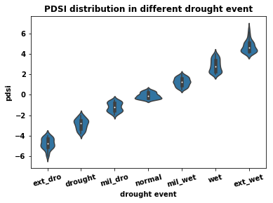

```python
base_color = sns.color_palette()[0]
sns.violinplot(data = ca_merge, x = 'dro_event', y = 'pdsi',
                  color = base_color)
plt.title('PDSI distribution in different drought event')
plt.xlabel('drought event')
plt.ylabel('pdsi')
plt.xticks(rotation = 15)
```

[output not shown]

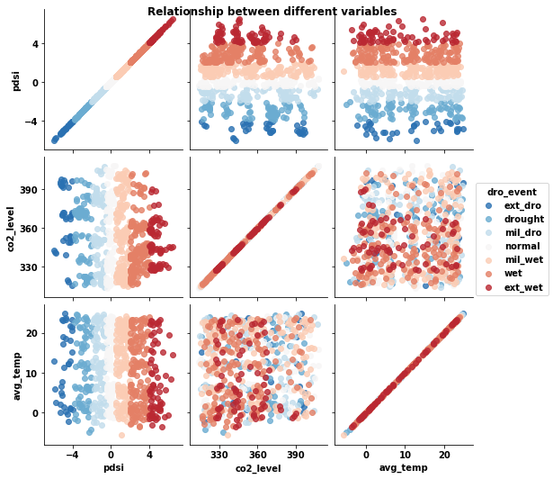

```python
#Data visulization to see any relationship between the variable
import matplotlib as mpl
#correlation
g=sns.PairGrid(ca_merge, vars=['pdsi', 'co2_level','avg_temp'],
              hue='dro_event', palette='RdBu_r')
g.map(plt.scatter, alpha=0.8)
g.add_legend()
for ax in g.axes.flat:
    ax.xaxis.set_major_locator(mpl.ticker.MaxNLocator(4, prune="both"))
    ax.yaxis.set_major_locator(mpl.ticker.MaxNLocator(4, prune="both"))
g.fig.subplots_adjust(hspace=.05, wspace=.05);
g.fig.suptitle('Relationship between different variables')
```

##### From above two plots, we didn't find any patterns or relation ship between drought events, CO2 level and average temperature. Thus, I calculated the mean temperature from 1960 - 1990 period to establish the California base mean temperature.The deviation from this temperature is added in the Anomaly column.

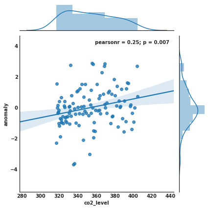

```python
#Now we try to see the relationship between CO2 level and anormaly based on different season
with sns.axes_style('white'):
    g=sns.jointplot('co2_level','anomaly', data=df_combine, kind='reg');
```

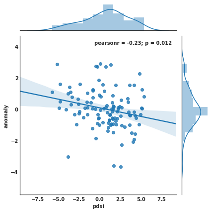

```python
# Now we try to see the relationship between pdsi and anormaly based on different season
with sns.axes_style('white'):
    g=sns.jointplot('pdsi','anomaly', data=df_combine, kind='reg');
```

#### Based on above two graphs, we can see that pdsi and temperature anormaly has negative correlation with very small p-value(0.012) and co2_level and temerature anormaly has positive correlation with very small p-value(0.007), which means we have statistically significant evidence to show the relationship between temperature and CO2 level, and the relationship between temperature and PDSI.

```python
#Create the dummie variables for the DROUGHT event given the low quatatitive relationship shown above
dummies = pd.get_dummies(df_combine['dro_event'])
new_df = df_combine.join(dummies)
new_df.head()
```

|  | StateCode | Division | YearMonth | PCP | avg_temp | pdsi | PHDI | ZNDX | PMDI | CDD | ... | Seasonally Adjusted CO2 Fit (ppm) | dro_event | anomaly | ext_dro | drought | mil_dro | normal | mil_wet | wet | ext_wet |
| --- | --- | --- | --- | --- | --- | --- | --- | --- | --- | --- | --- | --- | --- | --- | --- | --- | --- | --- | --- | --- | --- |
| 0 | 110 | 0 | 196002 | 2.59 | -0.822222 | 2.69 | 2.69 | 2.03 | 2.69 | 4 | ... | 316.64 | wet | -2.281944 | 0 | 0 | 0 | 0 | 0 | 1 | 0 |
| 1 | 110 | 0 | 196102 | 2.78 | 3.011111 | 0.39 | -1.25 | 1.17 | -0.62 | 8 | ... | 317.26 | normal | 1.551389 | 0 | 0 | 0 | 1 | 0 | 0 | 0 |
| 2 | 110 | 0 | 196202 | 2.55 | 1.622222 | 2.41 | 2.41 | 1.64 | 2.41 | 14 | ... | 318.19 | wet | 0.162500 | 0 | 0 | 0 | 0 | 0 | 1 | 0 |
| 3 | 110 | 0 | 196302 | 1.73 | 1.177778 | -2.53 | -2.53 | -2.06 | -2.53 | 4 | ... | 318.80 | drought | -0.281944 | 0 | 1 | 0 | 0 | 0 | 0 | 0 |
| 4 | 110 | 0 | 196502 | 2.16 | 0.288889 | 1.04 | -0.58 | 0.77 | 1.02 | 7 | ... | 319.71 | mil_wet | -1.170833 | 0 | 0 | 0 | 0 | 1 | 0 | 0 |

5 rows × 39 columns

```python
#Built the linear model, use normal pdsi as baseline
new_df['intercept'] = 1
lm = sm.OLS(new_df['anomaly'], new_df[['intercept','ext_dro','drought','mil_dro','mil_wet','wet','ext_wet']])
results = lm.fit()
results.summary()
```

OLS Regression Results

| Dep. Variable: | anomaly | R-squared: | 0.101 |
| --- | --- | --- | --- |
| Model: | OLS | Adj. R-squared: | 0.050 |
| Method: | Least Squares | F-statistic: | 1.981 |
| Date: | Mon, 06 May 2019 | Prob (F-statistic): | 0.0748 |
| Time: | 12:42:22 | Log-Likelihood: | -177.79 |
| No. Observations: | 113 | AIC: | 369.6 |
| Df Residuals: | 106 | BIC: | 388.7 |
| Df Model: | 6 |  |  |
| Covariance Type: | nonrobust |  |  |

|  | coef | std err | t | P>\|t\| | [0.025 | 0.975] |
| --- | --- | --- | --- | --- | --- | --- |
| intercept | 0.4487 | 0.301 | 1.490 | 0.139 | -0.148 | 1.046 |
| ext_dro | 0.5679 | 0.577 | 0.985 | 0.327 | -0.576 | 1.711 |
| drought | -0.2730 | 0.450 | -0.607 | 0.545 | -1.165 | 0.619 |
| mil_dro | -0.2045 | 0.450 | -0.455 | 0.650 | -1.096 | 0.687 |
| mil_wet | -0.6608 | 0.373 | -1.771 | 0.079 | -1.400 | 0.079 |
| wet | -0.9354 | 0.400 | -2.339 | 0.021 | -1.728 | -0.143 |
| ext_wet | -0.6027 | 0.441 | -1.367 | 0.175 | -1.477 | 0.271 |

| Omnibus: | 3.061 | Durbin-Watson: | 1.581 |
| --- | --- | --- | --- |
| Prob(Omnibus): | 0.216 | Jarque-Bera (JB): | 3.123 |
| Skew: | -0.071 | Prob(JB): | 0.210 |
| Kurtosis: | 3.802 | Cond. No. | 8.17 |

#### The linear model with dummy variables shows that only wet events will have significant statistics evidence of the relationship between the events and the temperature anormaly while the relationship between drought events and temperature anormaly is not as statistically significant as the relationship between the wet events and temperature anormaly.

# Conclusion

### Part2

> Based on above two regressional graphs, we can see that pdsi and temperature anormaly has negative correlation with very small p-value(0.012) and co2_level and temerature anormaly has positive correlation with very small p-value(0.007), which means we have statistically significant evidence to show the relationship between temperature and CO2 level, and the relationship between temperature and PDSI. The linear model with dummy variables shows that only wet events will have significant statistics evidence of the relationship between the events and the temperature anormaly while the relationship between drought events and temperature anormaly is not as statistically significant as the relationship between the wet events and temperature anormaly.

### Limitations

> The timespan of the pdsi data is relatively short No further composite analysis was used due to the time and capability limitation.